# **Hands-on with TensorFlow: Part A**

Let's see how TensorFlow works and build a deep neural network model using the MNIST dataset.

## Steps to be followed:

1. Import TensorFlow
2. Load the MNIST dataset
3. Create the model
4. Get predictions from the model
5. Apply softmax activation to the predictions
6. Define the loss function
7. Compile the model
8. Train the model
9. Evaluate the model
10. Create a probability model

## Step 1: Import TensorFlow

- Import TensorFlow and check its version.

```python
import tensorflow as tf
print("TensorFlow version:", tf.__version__)
```

```
TensorFlow version: 2.6.0
```

## Step 2: Load the MNIST dataset

- Load the MNIST dataset and normalize the input data by dividing the train and test sets by 255.

```python
mnist = tf.keras.datasets.mnist

(x_train, y_train), (x_test, y_test) = mnist.load_data()
x_train, x_test = x_train / 255.0, x_test / 255.0
```

**Observation:**

- The dataset has been downloaded.

## Step 3: Create the model

- Create a Sequential model with flatten, dense, and dropout layers.

```python
model = tf.keras.models.Sequential([
  tf.keras.layers.Flatten(input_shape=(28, 28)),
  tf.keras.layers.Dense(128, activation='relu'),
  tf.keras.layers.Dropout(0.2),
  tf.keras.layers.Dense(10)
])
```

## Step 4: Get predictions from the model

- Get the predictions from the model using the train data for one column, as the optimizer is not yet applied.

```python
predictions = model(x_train[:1]).numpy()
predictions
```

```
array([[-0.06152206, -0.18010066, -0.09845212,  0.19371796,  0.6763342 ,
         0.14202437, -0.10428441,  0.60308415,  0.5277651 , -0.16108146]],
      dtype=float32)
```

**Observation:**

- An array of predicted values is displayed.

## Step 5: Apply softmax activation to the predictions

- Apply softmax activation to the predictions and print the output in terms of probabilities.

```python
tf.nn.softmax(predictions).numpy()
```

```
array([[0.07651291, 0.06795739, 0.07373882, 0.09876068, 0.1600227 ,
        0.09378508, 0.07331001, 0.14872006, 0.13793005, 0.06926225]],
      dtype=float32)
```

**Observation:**

- The predicted values in terms of probabilities are displayed as an array.

## Step 6: Define the loss function

- Create a loss function for the model.
- Define the SparseCategoricalCrossentropy loss function.

```python
loss_fn = tf.keras.losses.SparseCategoricalCrossentropy(from_logits=True)
```

```python
loss_fn(y_train[:1], predictions).numpy()
```

```
2.3667493
```

**Observation:**

## Step 7: Compile the model

- Compile the model with the Adam optimizer, the loss function, and the accuracy metric.

```python
model.compile(optimizer='adam',
              loss=loss_fn,
              metrics=['accuracy'])
```

**Observation:**

- Here, we have used an optimizer as Adam, loss as a loss function, and metrics as accuracy.

## Step 8: Train the model

- Fit the model using the training data for 5 epochs.

```python
model.fit(x_train, y_train, epochs=5)
```

```
<keras.callbacks.History at 0x2d1949b4888>
```

**Observations:**

## Step 9: Evaluate the model

- Evaluate the model using the testing data and print the results.

```python
model.evaluate(x_test,  y_test, verbose=2)
```

```
313/313 - 2s - loss: 0.0748 - accuracy: 0.9769
```

```
[0.07478468865156174, 0.9768999814987183]
```

**Observation:**

## Step 10: Create a probability model

- Create a probability model by adding the softmax layer to the existing model.

```python
probability_model = tf.keras.Sequential([
  model,
  tf.keras.layers.Softmax()
])
```

- Get the predictions using the test data

```python
probability_model(x_test[:3])
```

```
<tf.Tensor: shape=(3, 10), dtype=float32, numpy=
array([[2.6004173e-08, 3.7265084e-09, 1.7718692e-07, 6.2171683e-05,
        1.8466090e-11, 1.4430191e-07, 3.0316700e-13, 9.9993598e-01,
        5.9931068e-08, 1.4726390e-06],
       [1.2057671e-08, 9.0584588e-05, 9.9985266e-01, 4.9673716e-05,
        4.5469093e-15, 6.7763858e-06, 2.7227788e-08, 1.7755311e-12,
        1.8827872e-07, 2.8722681e-13],
       [5.0886342e-08, 9.9899656e-01, 3.6835623e-05, 1.9061152e-06,
        1.8710571e-05, 1.4478415e-05, 2.2327516e-05, 8.1411359e-04,
        9.4268078e-05, 8.7836167e-07]], dtype=float32)>
```

```python
x_test.shape
```

```
(10000, 28, 28)
```

```python
a = probability_model(x_test[:3])
```

```python
import numpy as np
b = np.argmax(a, axis = 1)
b
```

```
array([7, 2, 1], dtype=int64)
```

[output not shown]

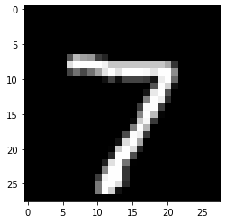

```python
import matplotlib.pyplot as plt
plt.imshow(x_test[0], cmap = 'gray')
```

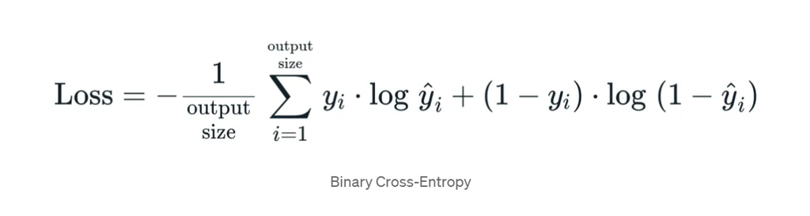

**Observation:**

- Here, we have the probabilities for the first three observations and different classes.

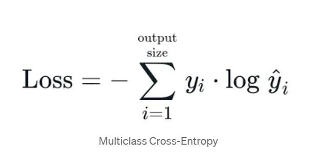

```python
# Define the Keras TensorBoard callback.
from tensorflow.keras.callbacks import TensorBoard
NAME = "demo"
tensorboard = TensorBoard(log_dir="logs/{}".format(NAME))

# Train the model.
model.fit(x_train, y_train, epochs=1,callbacks=[tensorboard])
```

```
<keras.callbacks.History at 0x2d293751c88>
```

```python
%load_ext tensorboard
%tensorboard --logdir logs --port 6009
```

```
The tensorboard extension is already loaded. To reload it, use:
  %reload_ext tensorboard
```

[interactive chart not shown]

```python
# import tensorflow as tf

# print("Num GPUs Available: ", len(tf.config.list_physical_devices('GPU')))
```

[output not shown]